# OncoSimulR: Frequency-dependent fitness

Sara Dorado Alfaro, Miguel Hernández del Valle, Álvaro Huertas García, Diego Mañanes Cayero and Alejandro Martín Muñoz

Universidad Autonoma de Madrid (UAM)

9 enero 2020

#### Package

OncoSimulR_Project

# 1 Introduction

In the current bullet point, several examples are shown below from the literature on frequency-dependent fitness corresponding to the proposed exercise 2 programming for the subject Programming and Statistics with R (Master’s Degree in Bioinformatics and Computational Biology, Universidad Autónoma de Madrid) [1] [2] [3] [7] [8] [10] [12].  
The OncoSimulR package [4][5][6] with the frequency-dependent fitness functionality has been used [11].

To generate the current vignette, the cascading style sheets (CSS) from the OncoSimulR package have been used with slight modifications to keep as much similarity as possible.

## 1.1 News and functions used

The OncoSimulR package and ggplot2 are required to generate the vignette plots. For reproducible vignette results the seed has been fixed. The number of cores used to run the simulations has also been set to 4 (in case of Windows it will always be 1 by default), although the user can modify it if he wishes. The parallel programming package named parallel is used with *L’Ecuyer-CMRG* random number generator (RNG) in order to take advantege of the benefit of parallel computing.

```r
## Packages
library(OncoSimulR)
library(ggplot2)

## Set a seed to oncoSimulIndiv
set.seed(1)

## Set a seed to oncoSimulPop to allow reproducibility
library(parallel)
RNGkind("L'Ecuyer-CMRG")

## To allow modify the number of cores used in the cases of parallelization,
## this macro can be set as the user wants
n_cores <- 4

## Get rid of the messages
options(stringsAsFactors = FALSE)
```

Box-plots allow representing the consensus of the last result between different simulations. This type of representation is not always the desired one. In cases with oscillating trajectories, it is preferable to represent the consensus between the means of the results from the middle of the simulation to its end between several simulations.

```r
## Import functions to plot box-plots and stripcharts
source("./Funciones_plot_markdown.R")

## Import modified plot.oncosimul for plotting legend outside the plot
source("legend_outside.R")
```

# 2 Rock-paper-scissors model in bacterial community

## 2.1 Introduction

This example is inspired by the article *Local dispersal promotes biodiversity* *in a real game of rock paper scissors* [8]. It describes the relationship between three populations of *Escherichia coli*, that turns out to be very similar to a rock-paper-scissors game.

An E. coli community can have a specific strain of colicinogenic bacteria, that are capable of creating colicin, a toxin to which this special strain is resistant. The wild-type bacteria is killed by this toxin, but can mutate into a resistant strain.

So, there are three kinds of bacteria: wild-type (WT), colicinogenic (C) and resistant (R). The presence of C reduces the population of WT, but increases the population of R because R has an advantage over C, since R doesn’t have the cost of creating the toxin. At the same time, WT has an advantage over R, because by losing the toxin receptors, R loses also some important functions. Therefore, every strain “wins” against one strain and “loses” against the other, creating a rock-paper-scissors game.

```r
crs <- function (a, b, c){
  data.frame(Genotype = c("WT", "C", "R"),
             Fitness = c(paste0("1 + ", a, " * f_2 - ", b, " * f_1"),
                         paste0("1 + ", b, " * f_ - ", c, " * f_2"),
                         paste0("1 + ", c, " * f_1 - ", a, " * f_")
             ))
}
```

The equations are:

```r
crs("a", "b", "c")
```

```
##   Genotype               Fitness
## 1       WT 1 + a * f_2 - b * f_1
## 2        C  1 + b * f_ - c * f_2
## 3        R  1 + c * f_1 - a * f_
```

## 2.2 Case 1

We are going to study the scenario in which all the relationships have the same relative weight.

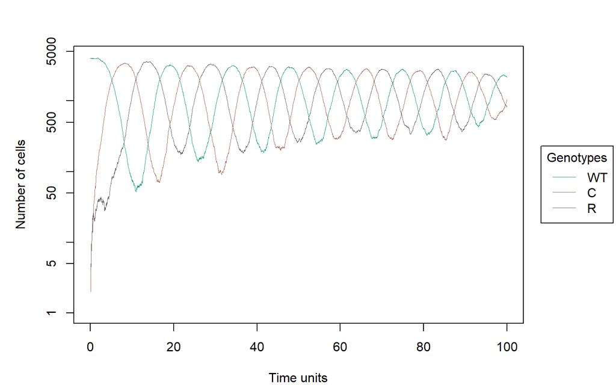

```r
afcrs1 <- allFitnessEffects(genotFitness = crs(1, 1, 1),
                           frequencyDependentFitness = TRUE,
                           frequencyType = "rel")

resultscrs1 <- oncoSimulIndiv(afcrs1,
                             model = "McFL",
                             onlyCancer = FALSE,
                             finalTime = 100,
                             mu = 1e-2,
                             initSize = 4000,
                             keepPhylog = TRUE,
                             seed = NULL,
                             errorHitMaxTries = FALSE,
                             errorHitWallTime = FALSE)

plot(resultscrs1, show = "genotypes", type = "line")
```

An oscillatory equilibrium is reached, in which the same populations have a similar number of individuals but oscillates. This makes sense, because the rise on a particular strand will lead to a rise in the one that “wins” against it, and then to a rise in the one that “wins” against the second one, creating this cyclical behaviour.

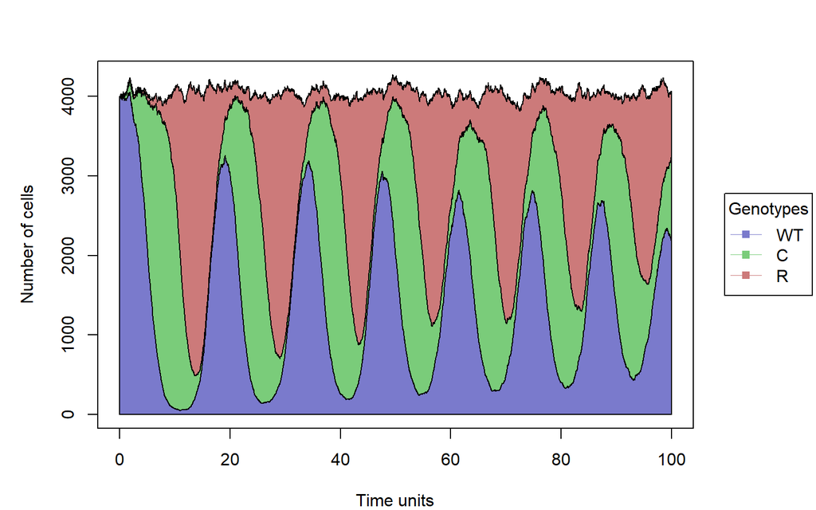

```r
plot(resultscrs1, show = "genotypes", type = "stacked")
```

In the stacked plot we can see that the total population remains almost constant.

## 2.3 Case 2

We are going to put a bigger weight in one of the coefficients, so a=10, b=1, c=1.

```r
afcrs2 <- allFitnessEffects(genotFitness = crs(10, 1, 1),
                           frequencyDependentFitness = TRUE,
                           frequencyType = "rel")

resultscrs2 <- oncoSimulPop(10,
                           afcrs2,
                             model = "McFL",
                             onlyCancer = FALSE,
                             finalTime = 100,
                             mu = 1e-2,
                             initSize = 4000,
                             keepPhylog = TRUE,
                             seed = NULL,
                             errorHitMaxTries = FALSE,
                             errorHitWallTime = FALSE)
```

The following chart represents the average number of cells of each type during the last half of each simulation. As a boxplot would lose the informationof the different scenarios, so we decided to plot the data as points and join with lines the ones that come from the same simulation.

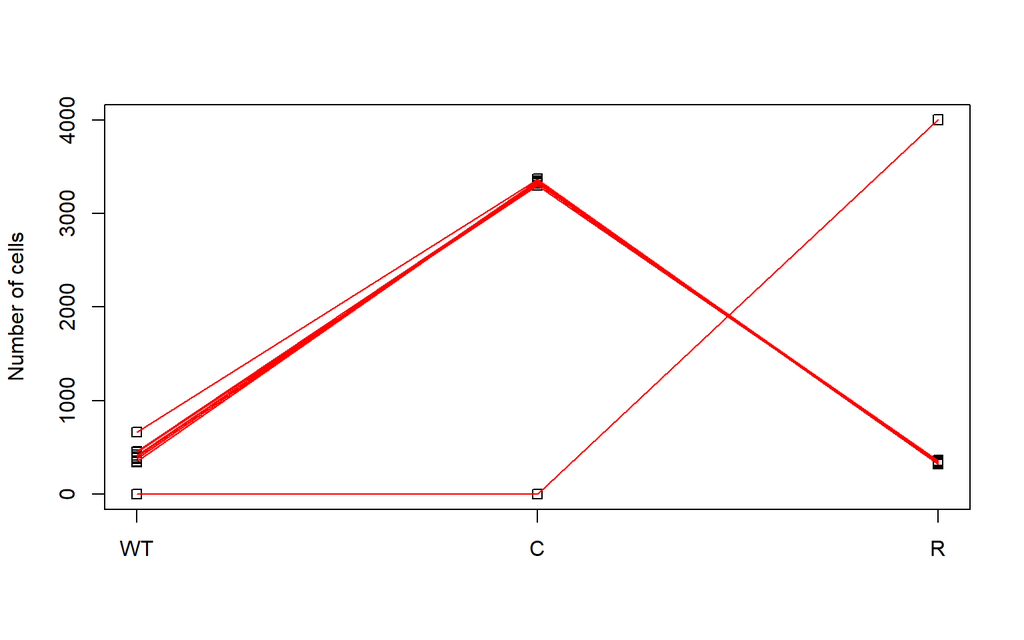

```
##          WT        C         R
## 1  663.3908 3366.098  328.8801
## 2    0.0000    0.000 4000.7876
## 3  380.9690 3335.346  341.9275
## 4  446.9860 3298.905  351.1634
## 5  455.5182 3333.330  360.0860
## 6  352.0625 3336.751  352.9860
## 7  347.9090 3340.257  322.6062
## 8  396.8416 3347.679  351.3603
## 9  347.2584 3339.395  347.7146
## 10 417.4098 3320.784  355.8196
```

```r
meanCompositionPop(resultscrs2, ylab = "Number of cells")
```

There are two scenarios. The first one is the one in which all the strains coexist, with the colicinogenic bacteria having a much bigger population.

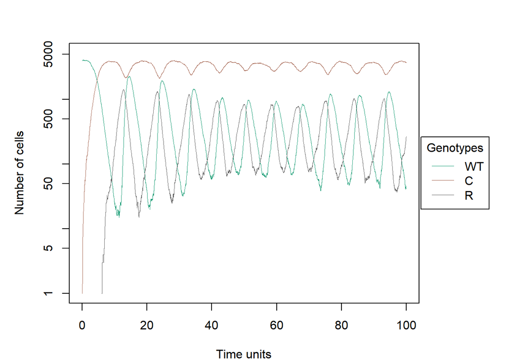

Coexistance scenario

In the second one, the wild type and the colicinogenic bacteria dissapear, so the resistant strain is the only one that survives.

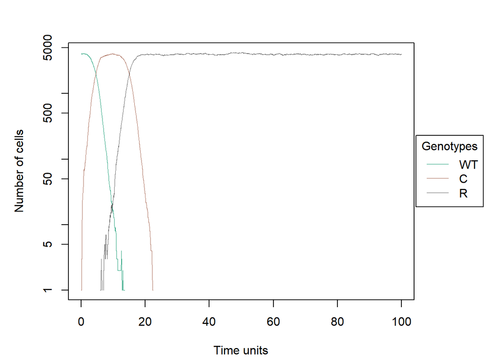

Only resistant strain

## 2.4 Case 3

Finally, we are going to put more weight in two coefficients, so a=1, b=5, c=5.

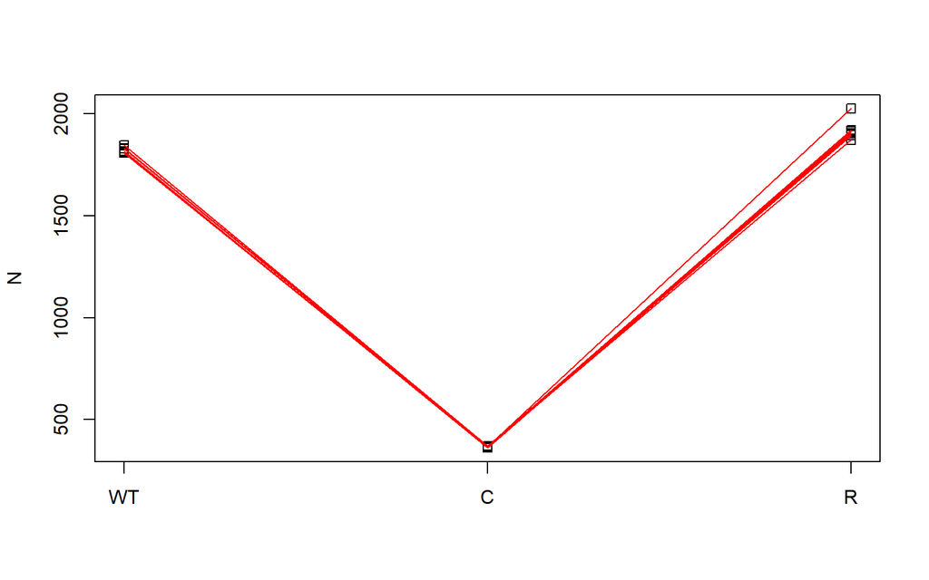

```
##          WT        C        R
## 1  1844.983 371.0765 1904.849
## 2  1813.722 368.9100 1901.602
## 3  1815.385 362.1104 1915.686
## 4  1811.409 370.8126 1903.086
## 5  1808.050 369.0585 2024.830
## 6  1814.256 368.9860 1894.020
## 7  1815.791 361.7611 1912.350
## 8  1829.423 371.6922 1919.068
## 9  1828.367 371.3463 1917.785
## 10 1844.200 368.2489 1871.187
```

```r
afcrs3 <- allFitnessEffects(genotFitness = crs(1, 5, 5),
                           frequencyDependentFitness = TRUE,
                           frequencyType = "rel")

resultscrs3 <- oncoSimulPop(10,
                           afcrs3,
                             model = "McFL",
                             onlyCancer = FALSE,
                             finalTime = 100,
                             mu = 1e-2,
                             initSize = 4000,
                             keepPhylog = TRUE,
                             seed = NULL,
                             errorHitMaxTries = FALSE,
                             errorHitWallTime = FALSE)

meanCompositionPop(resultscrs3)
```

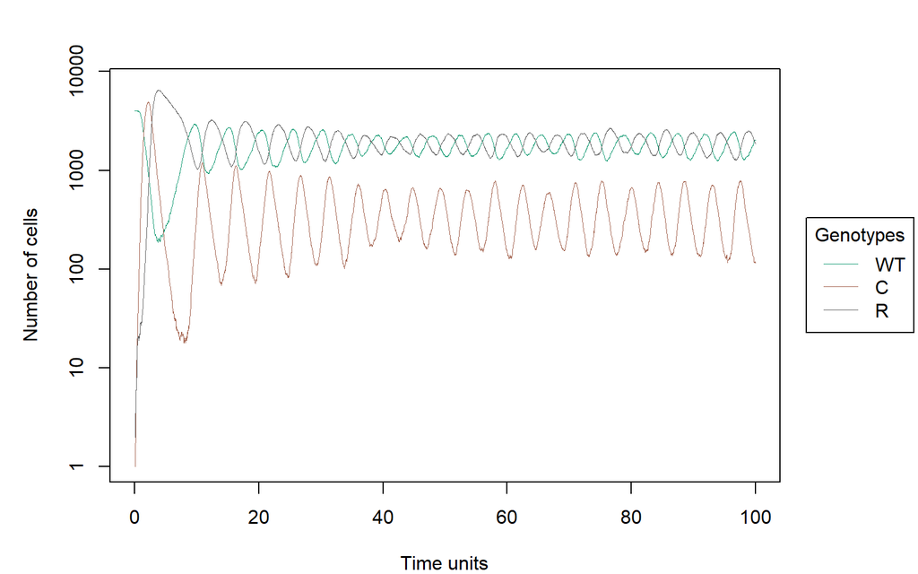

```r
plot(resultscrs3[[3]], show = "genotypes", type = "line")
```

In all the cases all three strains survive, with C having a much smaller population than the other two.

# 3 Evolutionary games theory: Hawk and Dove example

The example we are going to show is one of the first games that Maynar Smith analyzed. This classic game is: *Hawk and Dove* 3, available at https://en.wikipedia.org/wiki/Chicken_(game)).

In this game, the two competitors are subtypes of the same species but with different strategies. The Hawk first displays aggression, then escalates into a fight until it either wins or is injured (loses). The Dove first displays aggression, but if faced with major escalation runs for safety. If not faced with such escalation, the Dove attempts to share the resource.

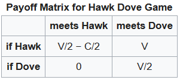

Payoff Matrix for Hawk Dove Game

Given that the resource is given the value V, the damage from losing a fight is given cost C:[1]

- If a Hawk meets a Dove he gets the full resource V to himself
- If a Hawk meets a Hawk – half the time he wins, half the time he loses… so his average outcome is then V/2 minus C/2
- If a Dove meets a Hawk he will back off and get nothing – 0
- If a Dove meets a Dove both share the resource and get V/2

The actual payoff however depends on the probability of meeting a Hawk or Dove, which in turn is a representation of the percentage of Hawks and Doves in the population when a particular contest takes place. That in turn is determined by the results of all of the previous contests. If the cost of losing C is greater than the value of winning V (the normal situation in the natural world) the mathematics ends in an stationary point (ESS), a mix of the two strategies where the population of Hawks is V/C.

In this case we assume a stable equilibrium in the population dynamics, that is, although there are external variations in the model, it recovers and returns to equilibrium (as shown in the image below).

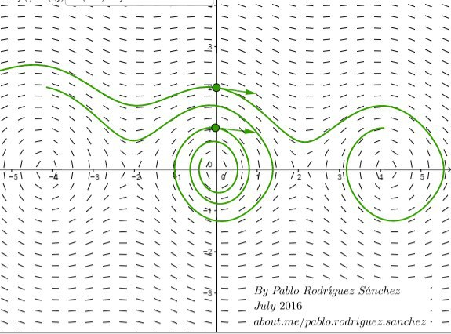

Stable equilibrium

We are going to simulate with OncoSimulR the situation in which the cost of losing C is greater than the value of gaining V (C = 10, V = 2). Before performing the simulation, let’s look at the fitness of each competitor.

```r
## Stablish Genotype-Fitnees mapping. D = Dove, H = Hawk
H_D_fitness <- function(c, v,
                    gt = c("WT", "H", "D")) {
  data.frame(Genotype = gt,
             Fitness = c(
               paste0("1"),
               paste0("1 + f_1 *", (v-c)/2, "+ f_2 *", v),
               paste0("1 + f_2 *", v/2)))
}

## Fitness Effects specification
HD_competition <-allFitnessEffects(
  genotFitness = H_D_fitness(10, 2,
                         gt = c("WT", "H", "D")),
  frequencyDependentFitness = TRUE,
  frequencyType = "rel",
  spPopSizes = c(5000, 5000, 5000))

## Plot fitness landscape of genotype "H, D" evaluation
data.frame("Doves_fitness" = evalGenotype(genotype = "D",
                                          fitnessEffects = HD_competition),
           "Hawks_fitness" = evalGenotype(genotype = "H",
                                          fitnessEffects = HD_competition))
```

```
##   Doves_fitness Hawks_fitness
## 1      1.333333     0.3333333
```

We observe that the penalty of fighting (C > V) benefits the dove in terms of fitness respect to the hawk.

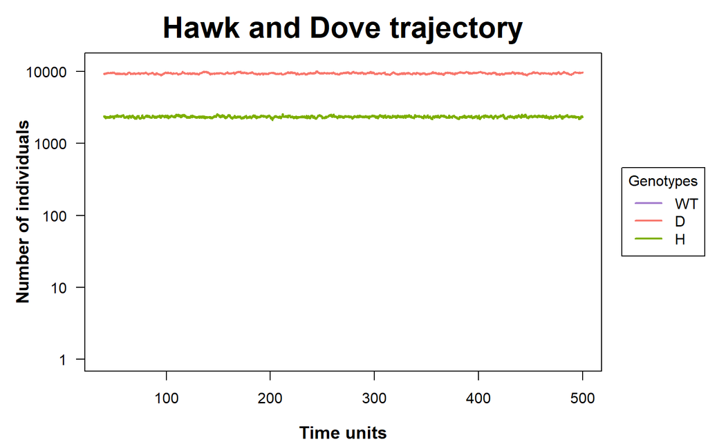

```r
## Simulated trajectories
simulation <- oncoSimulPop(20,
                           mc.cores = n_cores,
                           HD_competition,
                           model = "McFL", # There is no collapse
                           onlyCancer = FALSE,
                           finalTime = 500,
                           mu = 1e-2, # Quick emergence of D and H
                           initSize = 4000,
                           keepPhylog = TRUE,
                           seed = NULL,
                           errorHitMaxTries = FALSE,
                           errorHitWallTime = FALSE)



## Plot first trajectory as an example
plot(simulation[[1]], show = "genotypes", type = "line", xlim = c(40, 500),
     lwdClone = 2, ylab = "Number of individuals",
     main = "Hawk and Dove trajectory",
     col = c("#a37acc", "#f8776d", "#7daf00"),
     font.main=2, font.lab=2,
     cex.main=2, cex.lab=1.2,
     las = 1)
```

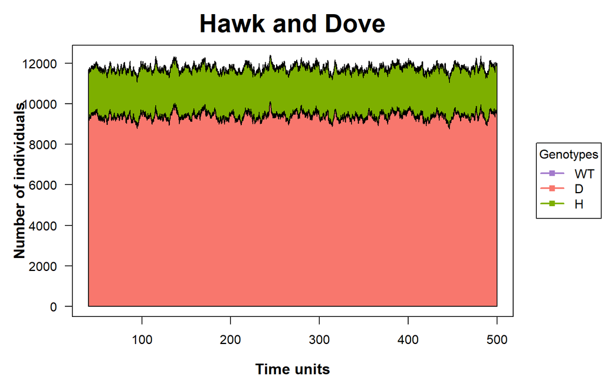

```r
plot(simulation[[1]], show = "genotypes", xlim = c(40, 500), lwdClone = 2,
     ylab = "Number of individuals", main = "Hawk and Dove",
     col = c("#a37acc", "#f8776d", "#7daf00"),
     font.main=2, font.lab=2,
     cex.main=2, cex.lab=1.2,
     las = 1)
```

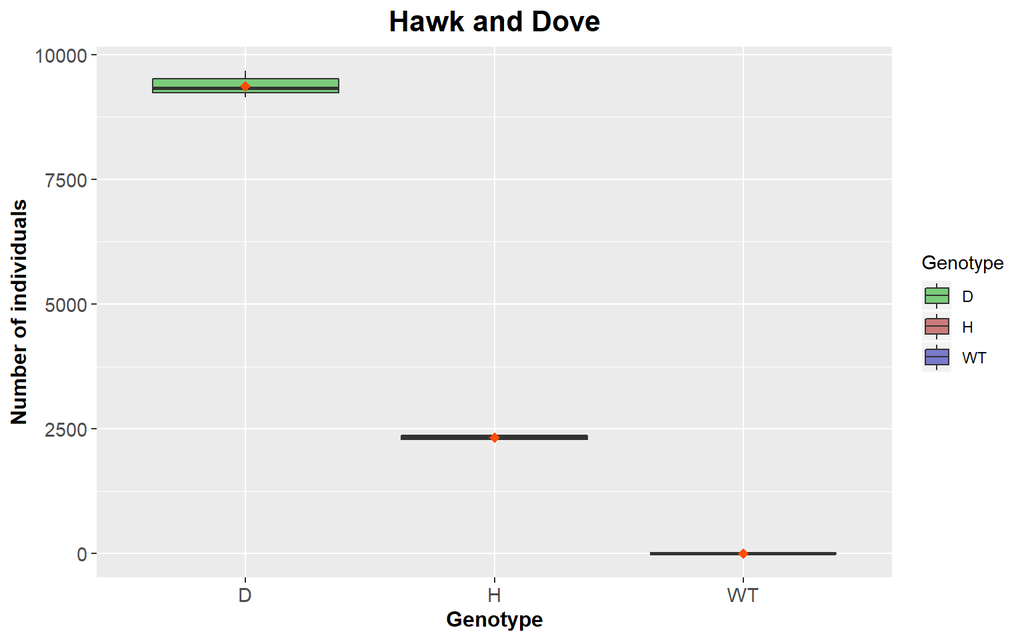

```r
## Agreement: Show boxplot from several simulations.
compositionPop2(simulation,
                ylab = "Number of individuals",
                main = "Hawk and Dove")
```

As mentioned above, mathematically when a stationary point (ESS) is reached the relative frequency of hawks is V/C and doves 1-(V/C). Considering f_H as relative frecuency of hawks and f_D = 1-f_H as frequency of doves:

Hawk:
$$1 + f_H*(v-c)/2 + (1-f_H)*v$$

Dove:
$$1 + (1-f_H)*v/2$$

Hawk = Dove:
$$1 + f_H*(v-c)/2 + (1-f_H)*v = 1 + (1-f_H)*v/2$$

Resolving for f_H:
$$f_H = v/c$$

Therefore, the relative frequency of hawks in equilibrium is equal to V/C. In our case it would be 20% (C = 10, V = 2). Let’s check it:

```r
## Recover the final result from first simulation
result <- tail(simulation[[1]][[1]], 1)

## Get the number of organisms from each species
n_WT <- result[2]
n_D <- result[3]
n_H <- result[4]
total <- n_WT + n_D + n_H

## Dove percentage
data.frame("Doves" = round(n_D/total, 2)*100,
           "Hawks" = round(n_H/total, 2)*100  )
```

```
##   Doves Hawks
## 1    81    19
```

To sum up, this example shows that when the risks of contest injury or death (the Cost C) is significantly greater than the potential reward (the benefit value V), the stable population will be mixed between aggressors and doves, and the proportion of doves will exceed that of the aggressors. This explains behaviours observed in nature.

# 4 The Lotka-Volterra model of competition between two competing species

Species do not exist in isolation of one another. The simple models of exponential and logistic growth fail to capture the fact that the growth of a species must depend on its interactions with other species (Otto and Day 2007). Including all possible factors in a model is very complex. However, there are models that focus on specific interactions and how they affect population growth, for example, Lotka-Volterra model.

The Lotka-Volterra model extends the logistic model by allowing multiple species to compete for resources, resulting in both inter-specific and intra-specific competition. In this part we will consider only two competing species (S1 and S2).

Competition model describe how the number of individuals of each species changes when other species uses the same resource.

The parameters considered in Lotka-Volterra model are: $n$ -> number of individuals $r$ -> Intrinsic growth rates $K$ -> Carrying capacities (max capacity of the environment) $a_{ij}$ -> competition coefficient. The effect of species j on species i

With these parameters, the continuous-time differential equations for the Lotka-Volterra model are:

$$\begin{align} \label{eq:Lotka_Volterra_1}
\frac{dn_1}{dt}= r_1n_1(t)\left(1-\frac{n_1(t)+a_{12}n_2(t)}{K_1}\right)
\end{align}$$
$$\begin{align} \label{eq:Lotka_Volterra_2}
\frac{dn_2}{dt}= r_2n_2(t)\left(1-\frac{n_2(t)+a_{21}n_1(t)}{K_2}\right)
\end{align}$$

As it is said above, the signs of $a_{12}$ and $a_{21}$ therefore reflect the relationship between the two species:

Table 1 Relationship between the two species

Table 1: Relationship between the two species

| a_12 | a_21 | Relationship |
| --- | --- | --- |
| - | - | Mutualistic |
| - | 0 | Commensal |
| 0 | - | Commensal |
| + | - | Parasitic |
| - | + | Parasitic |
| + | + | Competitive |
| + | 0 | Amensalism |
| 0 | + | Amensalism |

Next, to show the effect of competition coefficients and competition models we will model the scenarios proposed in the book *"Analysis and Management of* *Animal Populations"* [12]. For the following examples S1 and S2 will be the two species used, and can be interpreted as cellular clones competing for cellular resources or multicellular organisms competing for environmental resources (sexual or asexual reproduction is not relevant as it is incorporated in the birth rate).

S2 in these examples has a higher rate of growth than S1 ($r2 > r1$) and higher carrying capacity ($K2 > K1$). However, S1 has a stronger competitive effect on S2 ($a_{21} > a_{12}$).

Before seeing the examples, we have to keep in mind that in these models we treat resources as constant and the competition comes from the fight for resources, in any case is one of the species the resource.

```r
## Lotka-Volterra expressions for competition models
S1S2_LV <- function(r1, r2, K1, K2, a_12, a_21, awt = 1,
                    gt = c("WT", "S1", "S2")) {
  data.frame(Genotype = gt,
             Fitness = c(
               paste0("max(0.1, 1 - ", awt, " * (n_2 + n_1))"),
               paste0("1 + ", r1,
                      " * ( 1 - (n_1 + ", a_12, " * n_2)/", K1,
                      ")"),
               paste0("1 + ", r2,
                      " * ( 1 - (n_2 + ", a_21, " * n_1)/", K2,
                      ")")
             ))
}

## Show expressions for birth rates
S1S2_LV("r1", "r2", "K1", "K2", "a_12", "a_21", "awt")
```

```
##   Genotype                               Fitness
## 1       WT       max(0.1, 1 - awt * (n_2 + n_1))
## 2       S1 1 + r1 * ( 1 - (n_1 + a_12 * n_2)/K1)
## 3       S2 1 + r2 * ( 1 - (n_2 + a_21 * n_1)/K2)
```

## 4.1 Case 1: No competition

There is no competition, the competition coefficients are equal to 0. We see that the populations manage to reach their $K$ (maximum supported population). Due to S2 has greater capacity and growth rate, it reaches a population size greater than S1.

```r
## Case 1: No competition effects
## K2 > K1; r2 > r1 (species 2 has greater capacity and growth rate)
S1S2_competition <-allFitnessEffects(
    genotFitness = S1S2_LV(1.2, 1.7, 350, 400, 0, 0, ## a_12, a_21 are 0
              gt = c("WT", "S1", "S2")),
    frequencyDependentFitness = TRUE,
    frequencyType = "abs", ## frequency expressed in absolute terms
    spPopSizes = c(50, 50, 50)) ## Same population, lower than K

## Plot fitness landscape of genotype "S1, S2" evaluation
data.frame("S1_fitness" = evalGenotype(genotype = "S1",
                                       fitnessEffects = S1S2_competition),
           "S2_fitness" = evalGenotype(genotype = "S2",
                                       fitnessEffects = S1S2_competition))
```

```
##   S1_fitness S2_fitness
## 1   2.028571     2.4875
```

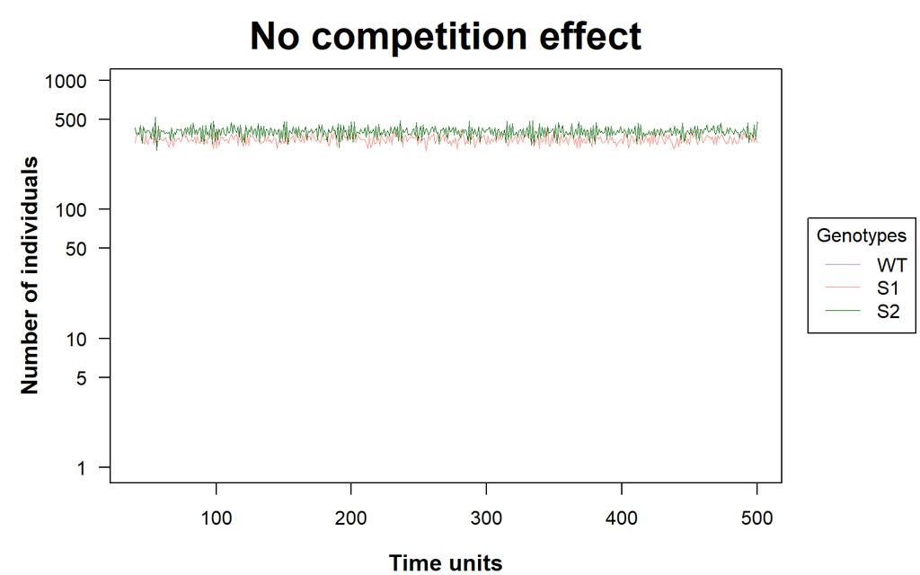

```r
S1S2_simulation <- oncoSimulPop(20, S1S2_competition, ## 10 simulations
                              model = "Exp",
                              mc.cores = n_cores,
                              onlyCancer = FALSE,
                              finalTime = 500,
                              mu = 1e-1, ## Allows appearance of S1 and S2
                              initSize = 4000,
                              seed = NULL,
                              errorHitMaxTries = FALSE,
                              errorHitWallTime = FALSE)



## Fitness values as an example
plot(S1S2_simulation[[1]], show = "genotypes", type = "line",
     xlim = c(40, 500),
     ylab = "Number of individuals",
     main = "No competition effect",
     col=c("#a37acc","salmon", "darkgreen"),
     font.main=2, font.lab=2,
     cex.main=2, cex.lab=1.2,
     las = 1)
```

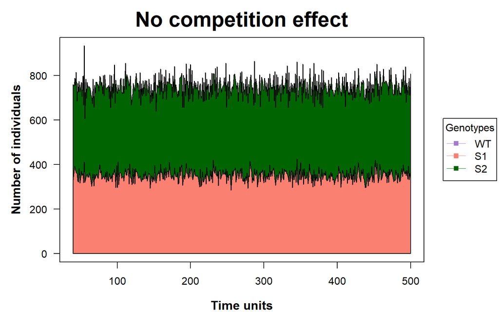

```r
plot(S1S2_simulation[[1]], show = "genotypes",
     xlim = c(40, 500),
     ylab = "Number of individuals",
     main = "No competition effect",
     col=c("#a37acc","salmon", "darkgreen"),
     font.main=2, font.lab=2,
     cex.main=2, cex.lab=1.2,
     las = 1)
```

It is also important to show a boxplot with the results of different simulations to check the reproducibility of the model.

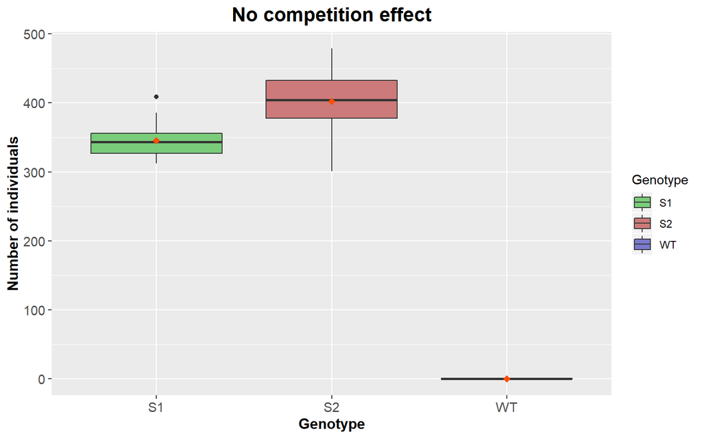

```r
## Agreement: Show boxplot from several simulations.
compositionPop2(S1S2_simulation, main = "No competition effect",
                ylab = "Number of individuals")
```

Before continuing with different scenarios, it is interesting to observe how the fitness landscape of the species S1 and S2 is influenced by the load capacity ($K$). In the absence of competition (exponential model), a fitness value larger than 1 indicates growth; a fitness value smaller than 1 indicates decline. Thus, when fitness is studied for populations of S1 and S2 with the size equal to K1 and K2 respectively, it is observed that the fitness is 1.

```r
## Case 1: No competition effects
S1S2_competition <-allFitnessEffects(
    genotFitness = S1S2_LV(1.2, 1.7, 350, 400, 0, 0,
              gt = c("WT", "S1", "S2")),
    frequencyDependentFitness = TRUE,
    frequencyType = "abs",
    spPopSizes = c(5, 350, 400)) ## spPopSizes equal to K1 and K2 respectively

## Fitness values of genotype "S1, S2" evaluation
data.frame("S1_fitness" = evalGenotype(genotype = "S1",
                                       fitnessEffects = S1S2_competition),
           "S2_fitness" = evalGenotype(genotype = "S2",
                                       fitnessEffects = S1S2_competition))
```

```
##   S1_fitness S2_fitness
## 1          1          1
```

In contrast, when spPopsizes is greater than K1 or K2 a population decrease is observed because the environment cannot support that size.

```r
## Case 1: No competition effects
S1S2_competition <-allFitnessEffects(
    genotFitness = S1S2_LV(1.2, 1.7, 350, 400, 0, 0,
              gt = c("WT", "S1", "S2")),
    frequencyDependentFitness = TRUE,
    frequencyType = "abs",
    spPopSizes = c(5, 500, 500)) ## spPopSizes higher than K1 and K2

## Fitness values of genotype "S1, S2" evaluation
data.frame("S1_fitness" = evalGenotype(genotype = "S1",
                                       fitnessEffects = S1S2_competition),
           "S2_fitness" = evalGenotype(genotype = "S2",
                                       fitnessEffects = S1S2_competition))
```

```
##   S1_fitness S2_fitness
## 1  0.4857143      0.575
```

## 4.2 Case 2: Stable coexistence

As described in page 166 from the book *"Analysis and Management of Animal* *Populations"* [9], if the numerators of the equilibrium formulas are positive, then the populations can coexist in equilibrium:

$$K1 > a_{12}*K2$$
$$K2 > a_{21}*K1$$

In this case, steady-state population (ESS) levels are simply the carrying capacieties K1 and K2, reduced by amounts $a_{12}*K2$ and $a_{21}*K1$, repectively, and scales by $1-a_{12}a_{21}$. Both populations converge to the equilibrium population levels irrespective of the initial population sices.

Considering:

- $K1$: 350
- $K2$: 400
- $a_{12}$: 0.25
- $a_{21}$: 0.5

$350 > 0.25*400$ and $400 > 0.5*350$

In this example we will see the stable coexistance of S1 and S2, which may change the final size of each population from the previous example.

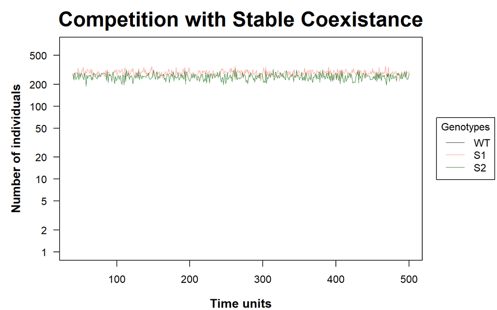

```r
## Case 2: Competition with Stable Coexistance
## K2 > K1; r2 > r1 (specie 2 has greater capacity and growth rate)
## a21 > a12 (specie 1 has more effect on specie 2)
S1S2_competition <-allFitnessEffects(
    genotFitness = S1S2_LV(1.2, 1.7, 350, 400, 0.25, 0.5,
              gt = c("WT", "S1", "S2")),
    frequencyDependentFitness = TRUE,
    frequencyType = "abs")


S1S2_simulation <- oncoSimulPop(20,
                                S1S2_competition,
                              model = "Exp",
                              mc.cores = n_cores,
                              onlyCancer = FALSE,
                              finalTime = 500,
                              mu = 1e-1,
                              initSize = 200,
                              keepPhylog = TRUE,
                              seed = NULL,
                              errorHitMaxTries = FALSE,
                              errorHitWallTime = FALSE)

## Plot first trajectory as an example
plot(S1S2_simulation[[1]], show = "genotypes", type = "line",
     xlim = c(40, 500),
     ylab = "Number of individuals",
     main = "Competition with Stable Coexistance",
     col=c("black","salmon", "darkgreen"),
     font.main=2, font.lab=2,
     cex.main=2, cex.lab=1.2,
     las = 1)
```

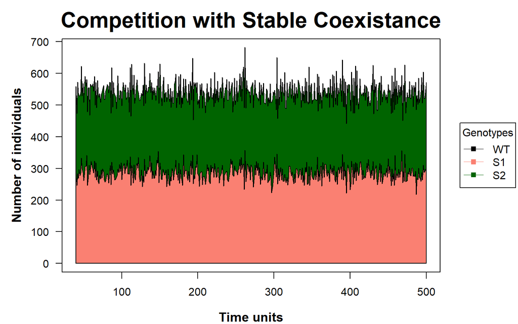

```r
plot(S1S2_simulation[[1]], show = "genotypes",
     xlim = c(40, 500),
     ylab = "Number of individuals",
     main = "Competition with Stable Coexistance",
     col=c("black","salmon", "darkgreen"),
     font.main=2, font.lab=2,
     cex.main=2, cex.lab=1.2,
     las = 1)
```

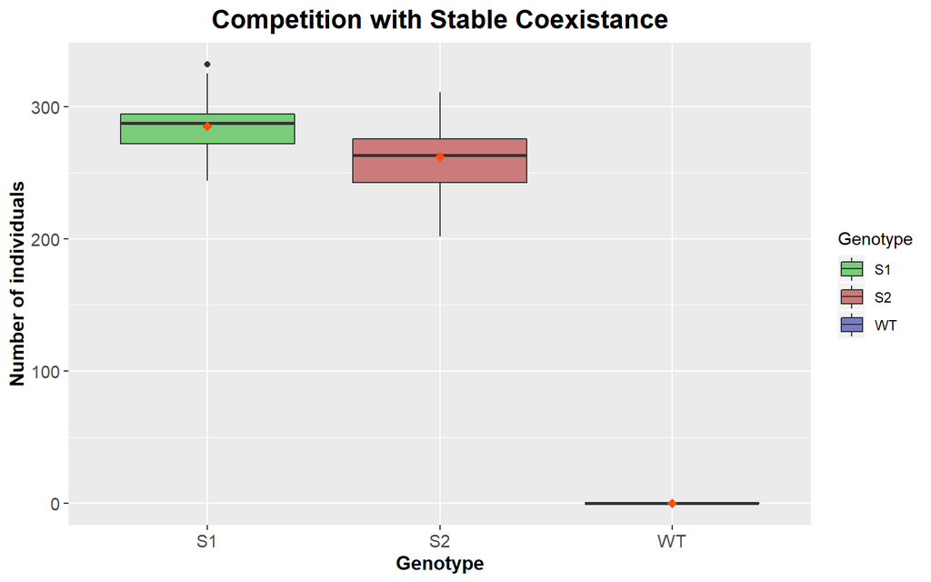

```r
## Agreement: Show boxplot from several simulations.
compositionPop2(S1S2_simulation, main = "Competition with Stable Coexistance",
                ylab = "Number of individuals")
```

As the previous case, if we analyze the fitness values for S1 and S2 we could check that initial population sizes lower than $n_1(t)$ and $n_2(t)$ lead to increases toward the steady-states values, this means fitness values higher than 1.

```r
S1S2_competition <-allFitnessEffects(
    genotFitness = S1S2_LV(1.2, 1.7, 350, 400, 0.25, 0.5,
              gt = c("WT", "S1", "S2")),
    frequencyDependentFitness = TRUE,
    frequencyType = "abs",
    spPopSizes = c(5, 50, 50)) ## lower initial sizes than ESS

## Fitness values of genotype "S1, S2" evaluation
data.frame("S1_fitness" = evalGenotype(genotype = "S1",
                                       fitnessEffects = S1S2_competition),
           "S2_fitness" = evalGenotype(genotype = "S2",
                                       fitnessEffects = S1S2_competition))
```

```
##   S1_fitness S2_fitness
## 1   1.985714    2.38125
```

Furthermore, initial population sizes higher than $n_1(t)$ and $n_2(t)$ lead to decreases toward the steady-states values, this means fitness values lower than 1.

```r
S1S2_competition <-allFitnessEffects(
    genotFitness = S1S2_LV(1.2, 1.7, 350, 400, 0.25, 0.5,
              gt = c("WT", "S1", "S2")),
    frequencyDependentFitness = TRUE,
    frequencyType = "abs",
    spPopSizes = c(5, 410, 410)) ## higher initial sizes than ESS

## Fitness values of genotype "S1, S2" evaluation
data.frame("S1_fitness" = evalGenotype(genotype = "S1",
                                       fitnessEffects = S1S2_competition),
           "S2_fitness" = evalGenotype(genotype = "S2",
                                       fitnessEffects = S1S2_competition))
```

```
##   S1_fitness S2_fitness
## 1  0.4428571    0.08625
```

## 4.3 Case 3: Competitive Exclusion

If only one of the two conditions $K1 > a_{12}*K2$ or $K2 > a_{21}*K1$ is achived the corresponding population eventually approaches its carrying capacity (irrespective of population initial size) and the other population is driven to extinction.

Considering:

- $K1$: 350
- $K2$: 400
- $a_{12}$: 0.5
- $a_{21}$: 1.2

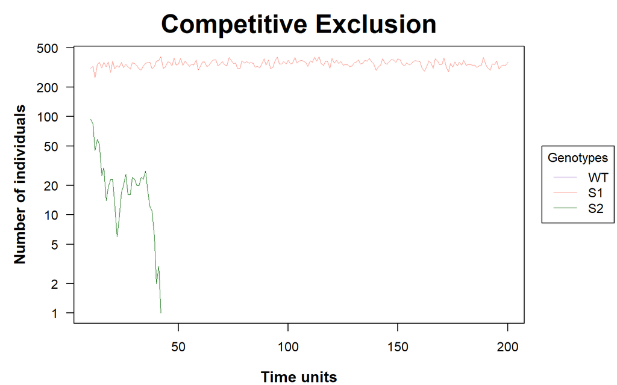

```r
## Test 3: Estable competition but more aggressive
S1S2_competition <-
  allFitnessEffects(
    genotFitness =
      S1S2_LV(1, 1.7, 350, 400, 0.5 , 1.2,
              gt = c("WT", "S1", "S2")),
    frequencyDependentFitness = TRUE,
    frequencyType = "abs")

S1S2_simulation <- oncoSimulPop(20, S1S2_competition,
                              model = "Exp",
                              mc.cores = n_cores,
                              onlyCancer = FALSE,
                              finalTime = 200,
                              mu = 1e-1,
                              initSize = 200,
                              keepPhylog = TRUE,
                              seed = NULL,
                              errorHitMaxTries = FALSE,
                              errorHitWallTime = FALSE)

## Plot first trajectory as an example
plot(S1S2_simulation[[1]], show = "genotypes", type = "line",
     xlim = c(10, 200),
     ylab = "Number of individuals",
     main = "Competitive Exclusion",
     col=c("#a37acc","salmon", "darkgreen"),
     font.main=2, font.lab=2,
     cex.main=2, cex.lab=1.2,
     las = 1)
```

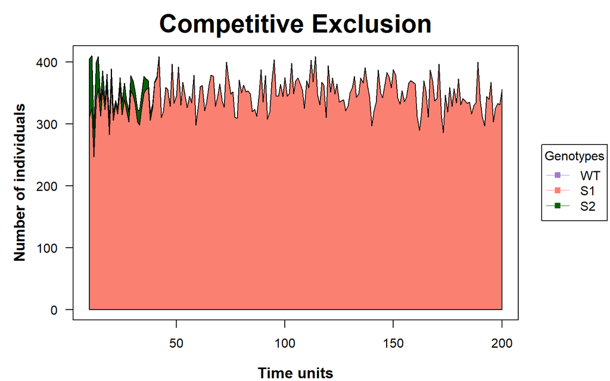

```r
plot(S1S2_simulation[[1]], show = "genotypes",
     xlim = c(10, 200),
     ylab = "Number of individuals",
     main = "Competitive Exclusion",
     col=c("#a37acc","salmon", "darkgreen"),
     font.main=2, font.lab=2,
     cex.main=2, cex.lab=1.2,
     las = 1)
```

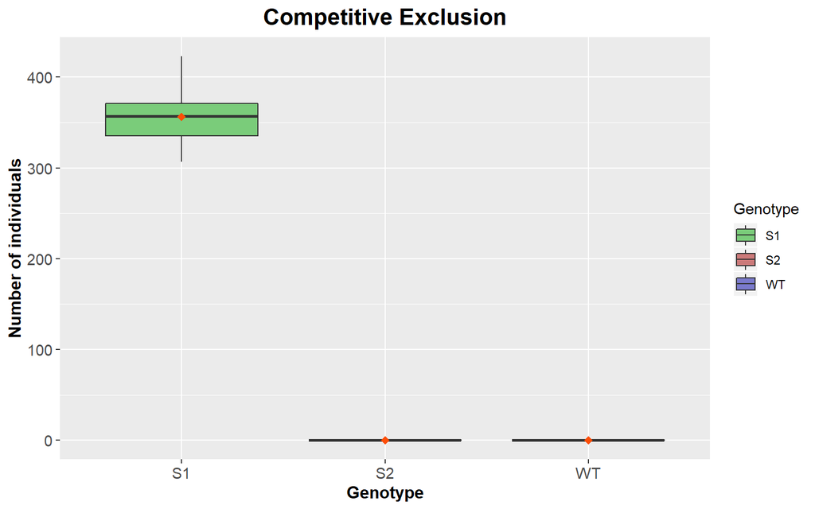

```r
## Agreement: Show boxplot from several simulations.
compositionPop2(S1S2_simulation, main = "Competitive Exclusion",
                ylab = "Number of individuals")
```

## 4.4 Case 4: Unstable Population Equilibrium

If both condition are:

$K1 < a_{12}*K2$  
$K2 < a_{21}*K1$

The population sizes never reach to equilibrium, so always one of the competitors will be extinct. The extincted competitor will depend on:

$$\begin{align} \label{Unstable Population}
n_2 > \frac{K_2-a_{12}K_1}{K_1-a_{21}K_2}\ n_1
\end{align}$$

where $n_1$ will be extincted. Or:

$$\begin{align} \label{eq1}
n_2 < \frac{K_2-a_{12}K_1}{K_1-a_{21}K_2}\ n_1
\end{align}$$

where $n_2$ will be extincted.

This is because, as we explained before, the steady-state population levels scaled by $1-a_{12}a_{21}$. In these scenarios: $a_{12}a_{21}>1$, so the steady-state population will never be reached.

In the first example we have:

- $K1$: 350
- $K2$: 400
- $a_{12}$: 1
- $a_{21}$: 1.4

$n_2 > 1.8n_1$

Since the mutation rate for S1 and S2 is the same (mu = 0.1), we can conclude that the initial population of n_1 and _n2 will be approximately equal to the same t. Thus the right-hand term is larger than the left-hand term. Therefore, S2 will be extincted:

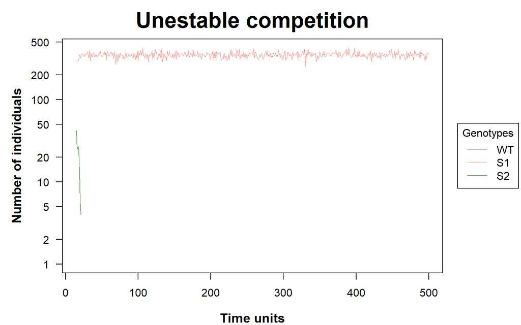

```r
## Test 4: Unestable competition
S1S2_competition <-
  allFitnessEffects(
    genotFitness =
      S1S2_LV(1.2, 1.7, 350, 400, 1, 1.4, ## notice coefficients
              gt = c("WT", "S1", "S2")),
    frequencyDependentFitness = TRUE,
    frequencyType = "abs")

S1S2_simulation <- oncoSimulPop(20, S1S2_competition,
                              model = "Exp",
                              mc.cores = n_cores,
                              onlyCancer = FALSE,
                              finalTime = 500,
                              mu = 1e-1,
                              initSize = 4000,
                              keepPhylog = TRUE,
                              seed = NULL,
                              errorHitMaxTries = FALSE,
                              errorHitWallTime = FALSE)

## Plot first trajectory as an example
plot(S1S2_simulation[[1]], show = "genotypes", type = "line",
     xlim = c(15, 500),
     ylab = "Number of individuals",
     main = "Unestable competition",
     col=c("#a37acc", "salmon", "darkgreen"),
     font.main=2, font.lab=2,
     cex.main=2, cex.lab=1.2,
     las = 1)
```

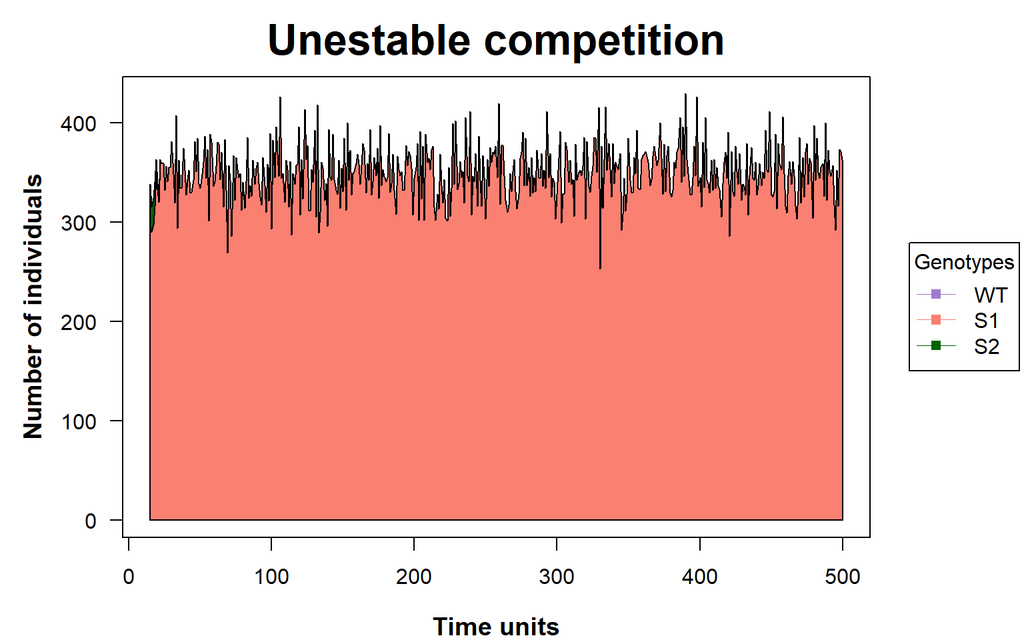

```r
plot(S1S2_simulation[[1]], show = "genotypes",
     xlim = c(15, 500),
     ylab = "Number of individuals",
     main = "Unestable competition",
     col=c("#a37acc", "salmon", "darkgreen"),
     font.main=2, font.lab=2,
     cex.main=2, cex.lab=1.2,
     las = 1)
```

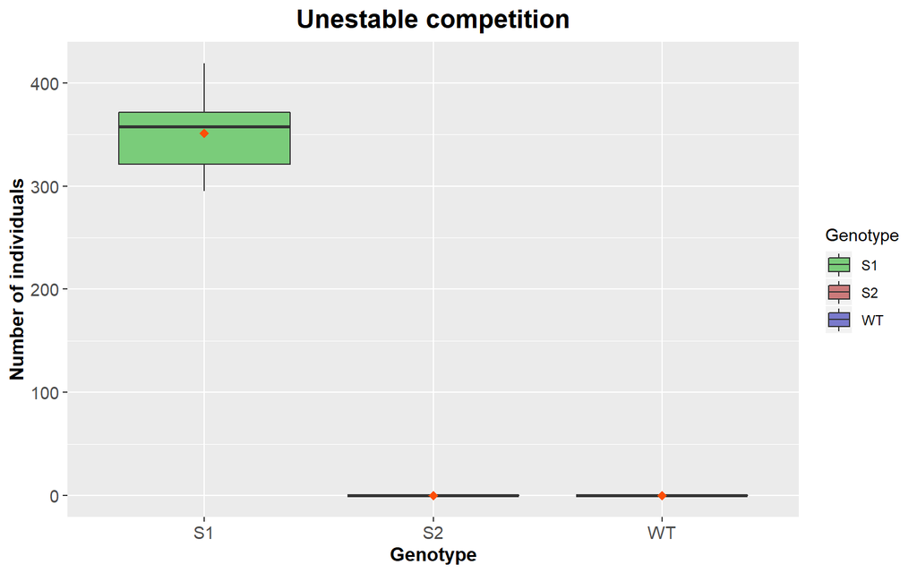

```r
## Agreement: Show boxplot from several simulations.
compositionPop2(S1S2_simulation, main = "Unestable competition",
                ylab = "Number of individuals")
```

In contrast, in the next example we have:

- $K1$: 350
- $K2$: 400
- $a_{12}$: 1
- $a_{21}$: 1.2

$n_2 < 0.4n_1$ Thus the right-hand term is lower than the left-hand term. Therefore, S1 will be extincted:

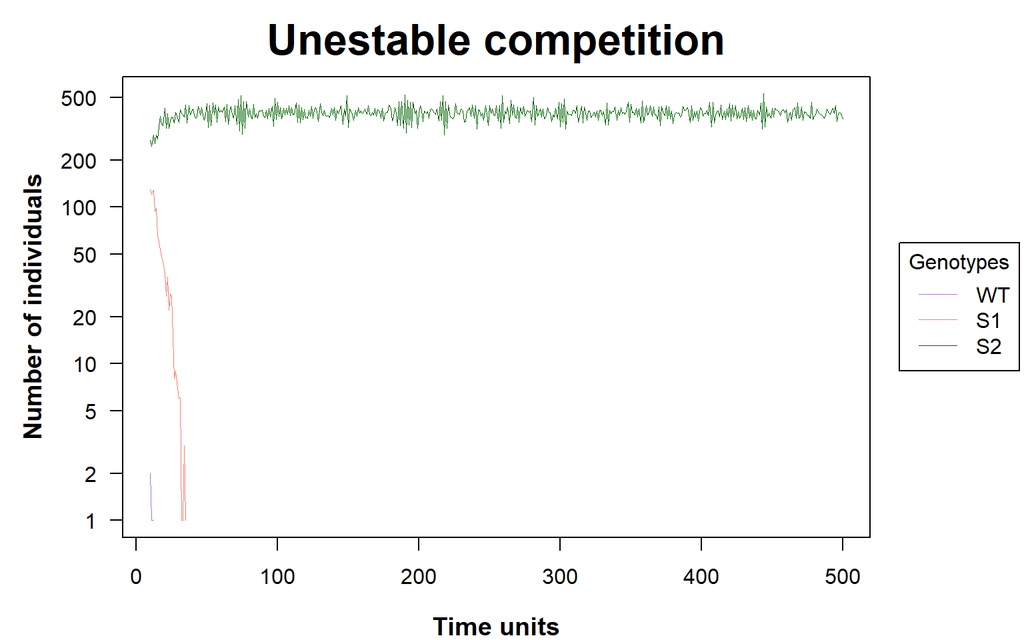

```r
## Test 4: Unestable competition
S1S2_competition <-
  allFitnessEffects(
    genotFitness =
      S1S2_LV(1.2, 1.7, 350, 400, 1, 1.2, ## notice coefficients
              gt = c("WT", "S1", "S2")),
    frequencyDependentFitness = TRUE,
    frequencyType = "abs")

S1S2_simulation <- oncoSimulPop(20, S1S2_competition,
                              model = "Exp",
                              mc.cores = n_cores,
                              onlyCancer = FALSE,
                              finalTime = 500,
                              mu = 1e-1,
                              initSize = 4000,
                              keepPhylog = TRUE,
                              seed = NULL,
                              errorHitMaxTries = FALSE,
                              errorHitWallTime = FALSE)

## Plot first trajectory as an example
plot(S1S2_simulation[[1]], show = "genotypes", type = "line",
     xlim = c(10, 500),
     ylab = "Number of individuals",
     main = "Unestable competition",
     col=c("#a37acc","salmon", "darkgreen"),
     font.main=2, font.lab=2,
     cex.main=2, cex.lab=1.2,
     las = 1)
```

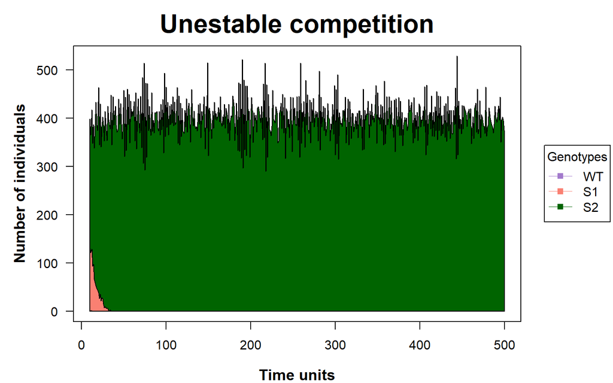

```r
plot(S1S2_simulation[[1]], show = "genotypes",
     xlim = c(10, 500),
     ylab = "Number of individuals",
     main = "Unestable competition",
     col=c("#a37acc","salmon", "darkgreen"),
     font.main=2, font.lab=2,
     cex.main=2, cex.lab=1.2,
     las = 1)
```

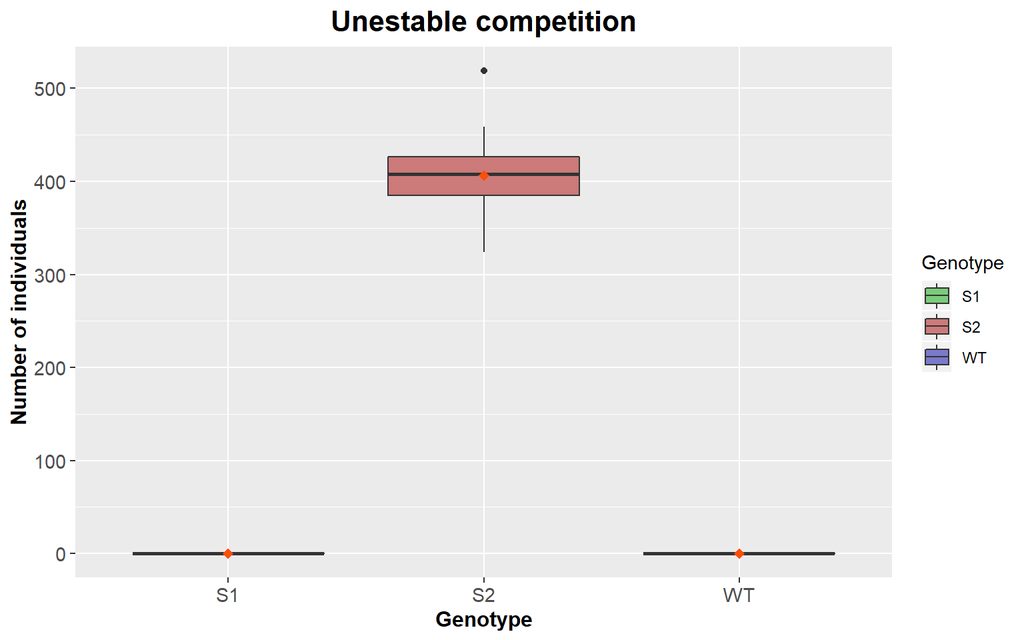

```r
## Agreement: Show boxplot from several simulations.
compositionPop2(S1S2_simulation, main = "Unestable competition",
                ylab = "Number of individuals")
```

# 5 Game Theory with social dilemmas of tumour acidity and vasculature

This example is based on the paper *Cancer treatment scheduling and dynamic* *heterogeneity in social dilemmas of tumour acidity and vasculature* [7], available at https://doi.org/10.1038/bjc.2017.5.

In this work, it is explained that the progression of cancer is marked by the acquisition of a number of hallmarks, including self-sufficiency of growth factor production for angiogenesis and reprogramming energy metabolism for aerobic glycolysis. Moreover, there is evidence of intra-tumour heterogeneity. Given that some cancer cells can not invest in something that benefits the whole tumor while others can free-ride on the benefits created by them (evolutionary social dilemmas), how do these population level traits evolve, and how are they maintained? The authors answer this question with a mathematical model that treats acid production through glycolysis as a tumour-wide public good that is coupled to the club good of oxygen from better vascularisation.

The cell types of the model are:

- VOP: VEGF (over)-producers.
- GLY: glycolytic cells.
- DEF: aerobic cells that do not call for more vasculature.

On the other hand, the micro-environmental parameters of the model are:

- a: the benefit per unit of acidification.
- v: the benefit from oxygen per unit of vascularisation.
- c: the cost of (over)-producing VEGF.

The fitness equations derived from those populations and parameters are:

$$\begin{equation}
W\left(GLY\right) = 1 + a * \left(f_1 + 1\right)
\end{equation}$$
$$\begin{equation}
W\left(VOP\right) = 1 + a * f_1 + v * \left(f_2 + 1\right) - c
\end{equation}$$
$$\begin{equation}
W\left(DEF\right) = 1 + a * f_1 + v * f_2
\end{equation}$$

Where $f_1$ is the GLY cells’ frequency and $f_2$ is the DEF cells’ frequency at a given time. All fitness equations start from balance by the sum of 1.

Finally, depending of the parameter’s values, the presented model can lead to three different situations:

## 5.1 Fully glycolytic tumours:

If the fitness benefit of a single unit of acidification is higher than the maximum benefit from the club good for aerobic cells, then GLY cells will always have a strictly higher fitness than aerobic cells, and be selected for. In this scenario, the population will converge towards all GLY, regardless of the initial proportions (as long as there is at least some GLY in the population).

```r
# Definition of the function for creating the corresponding dataframe.
avc <- function (a, v, c) {
  data.frame(Genotype = c("WT", "GLY", "VOP", "DEF"),
             Fitness = c("1",
                         paste0("1 + ",a," * (f_1 + 1)"),
                         paste0("1 + ",a," * f_1 + ",v," * (f_2 + 1) - ",c),
                         paste0("1 + ",a," * f_1 + ",v," * f_2")
                         ))
                          }

# Specification of the different effects on fitness.
afavc <- allFitnessEffects(genotFitness = avc(2.5, 2, 1),
                           frequencyDependentFitness = TRUE,
                           frequencyType = "rel")

# Launching of the simulation (20 times).
simulation <- oncoSimulPop(20,
                           mc.cores = n_cores,
                           afavc,
                           model = "McFL",
                           onlyCancer = FALSE,
                           finalTime = 25,
                           mu = 1e-2,
                           initSize = 4000,
                           keepPhylog = TRUE,
                           seed = NULL,
                           errorHitMaxTries = FALSE,
                           errorHitWallTime = FALSE)
```

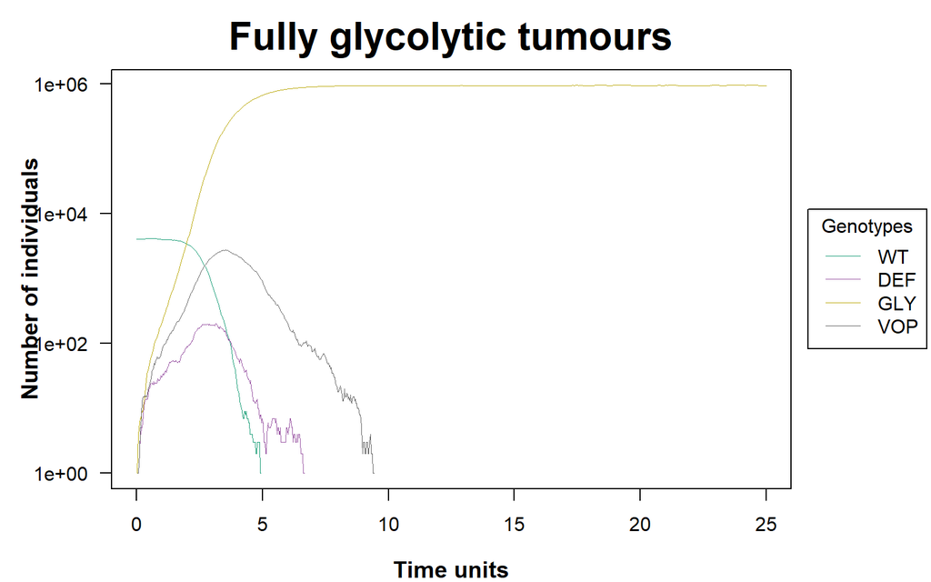

```r
# Representation of the plot of one simulation as an example (the others are
# highly similar).
plot(simulation[[1]], show = "genotypes", type = "line",
     ylab = "Number of individuals", main = "Fully glycolytic tumours",
     font.main=2, font.lab=2, cex.main=2, cex.lab=1.2, las = 1)
```

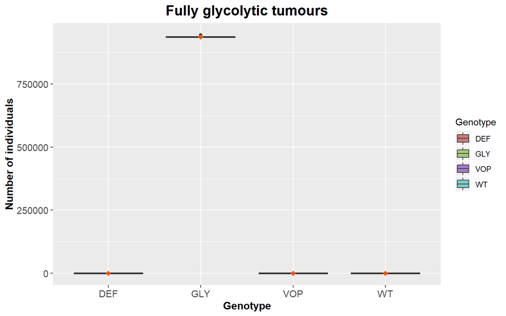

```r
# Representation of a boxplot considering all the simulations.
compositionPop2(simulation, ylab = "Number of individuals",
                main = "Fully glycolytic tumours")
```

## 5.2 Fully angiogenic tumours:

If the benefit to VOP from their extra unit of vascularisation is higher than the cost c to produce that unit, then VOP will always have a strictly higher fitness than DEF, selecting the proportion of VOP cells towards 1. In addition, if the maximum possible benefit of the club good to aerobic cells is higher than the benefit of an extra unit of acidification, then for sufficiently high number of VOP, GLY will have lower fitness than aerobic cells. When both conditions are satisfied, the population will converge towards all VOP.

```r
# Definition of the function for creating the corresponding dataframe.
avc <- function (a, v, c) {
  data.frame(Genotype = c("WT", "GLY", "VOP", "DEF"),
             Fitness = c("1",
                         paste0("1 + ",a," * (f_1 + 1)"),
                         paste0("1 + ",a," * f_1 + ",v, " * (f_2 + 1) - ",c),
                         paste0("1 + ",a," * f_1 + ",v, " * f_2")
                         ))
                          }

# Specification of the different effects on fitness.
afavc <- allFitnessEffects(genotFitness = avc(2.5, 7, 1),
                           frequencyDependentFitness = TRUE,
                           frequencyType = "rel")

# Launching of the simulation (20 times).
simulation <- oncoSimulPop(20,
                           mc.cores = n_cores,
                           afavc,
                           model = "McFL",
                           onlyCancer = FALSE,
                           finalTime = 25,
                           mu = 1e-2,
                           initSize = 4000,
                           keepPhylog = TRUE,
                           seed = NULL,
                           errorHitMaxTries = FALSE,
                           errorHitWallTime = FALSE)
```

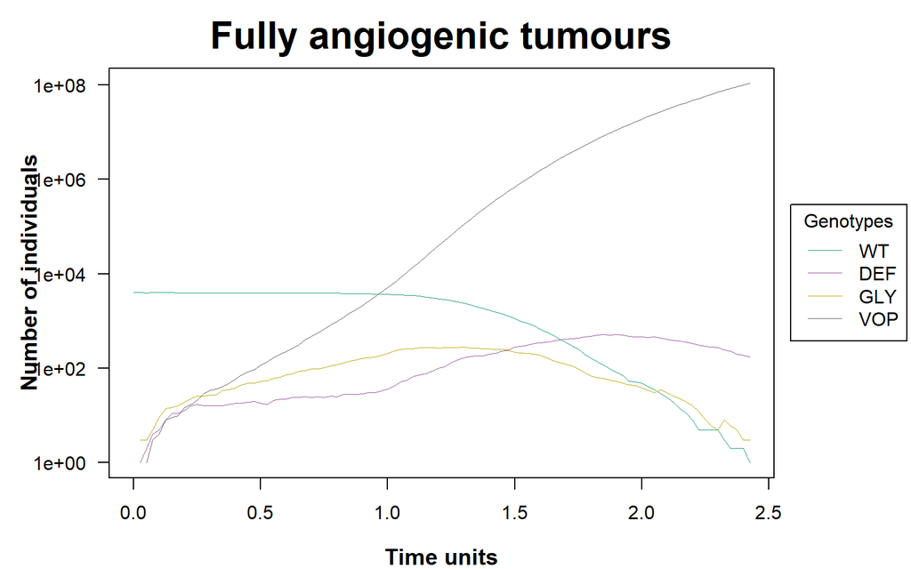

```r
# Representation of the plot of one simulation as an example (the others are
# highly similar).
plot(simulation[[1]], show = "genotypes", type = "line",
     ylab = "Number of individuals", main = "Fully angiogenic tumours",
     font.main=2, font.lab=2, cex.main=2, cex.lab=1.2, las = 1)
```

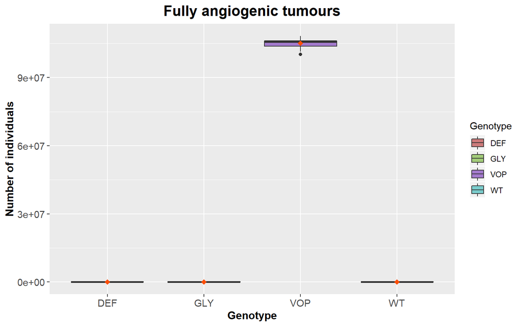

```r
# Representation of a boxplot considering all the simulations.
compositionPop2(simulation, ylab = "Number of individuals",
                main = "Fully angiogenic tumours")
```